# Regressão linear

GUILHERME OLIVEIRA CASAGRANDE

2023-10-31

## TV por assinatura

Uma pesquisa foi realizada, a fim de investigar as relações entre confiança, lealdade, comprometimento e intenção de recompra.

O estudo foi realizado com consumidores de TV por assinatura e de diferentes provedores de serviço, em 2015.

### ETAPA DESCRITIVA

1. Construir o diagrama de dispersão entre SAC (*complaint handling*) e confiança (*trust*).

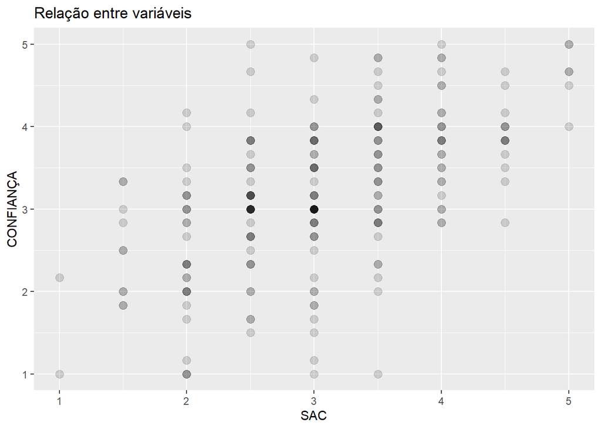

Quando há muita sobreposição dos pontos, é melhor usar transparência e aumentar o tamanho dos pontos.

O parâmetro alpha cria lâminas que vão ficando mais escuras à medida que a sobreposição aumenta.

Existe uma geometria chamada jitter que vai gerar uma perturbação aleatória entre 0 e 1 e multiplicar cada ponto.

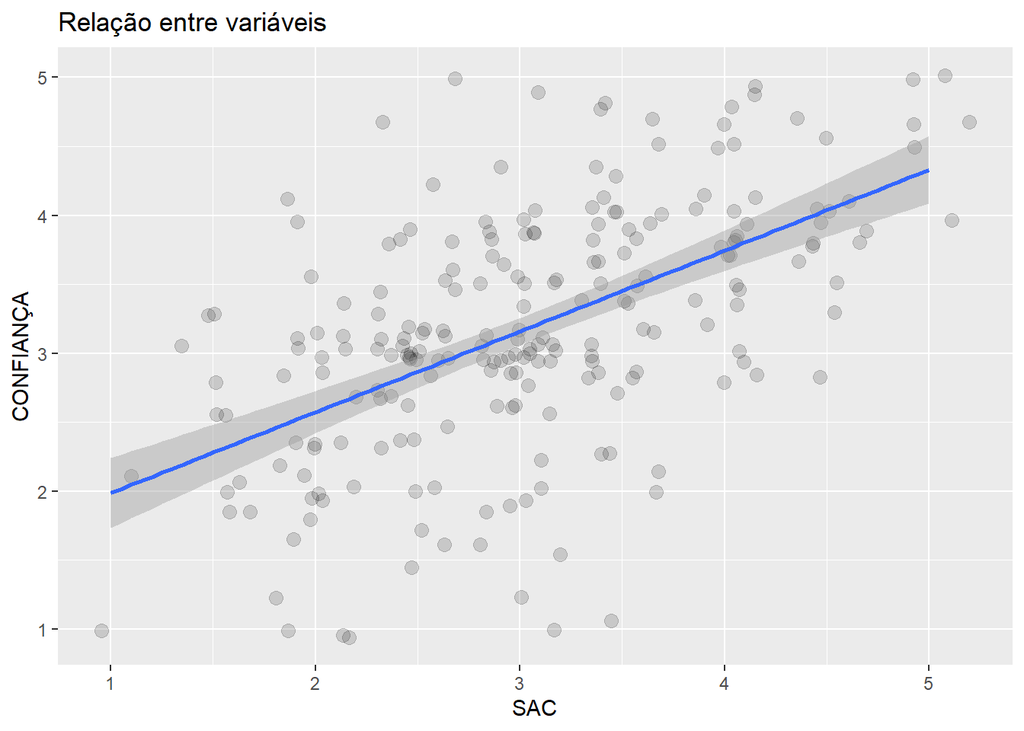

A geometria jitter só modifica a apresentação gráfica, mas não altera os valores das respostas.

A relação entre as variáveis parece ser da seguinte maneira: quando a nota que o consumidor atribui ao SAC aumenta, a confiança também aumenta. A relação é diretamente proporcional.

2. Calcular e interpretar a correlação

```
## [1] 0.56
```

O valor da correlação igual a 0.56 indica que o efeito da nota dada ao SAC sobre a confiança é moderado.

### ETAPA INFERENCIAL

3. Encontrar a equação de regressão e interpretar a inclinação da reta.

Equação de regressão

|  | Estimate | Std. Error | t value | Pr(>\|t\|) |
| --- | --- | --- | --- | --- |
| (Intercept) | 1.40 | 0.18 | 7.62 | 0 |
| x | 0.59 | 0.06 | 10.06 | 0 |

Limites

|  | 2.5 % | 97.5 % |
| --- | --- | --- |
| (Intercept) | 1.04 | 1.76 |
| x | 0.47 | 0.70 |

A Tabela 1 mostra a equação na coluna “Estimate. Ela é dada por:
$$y = 1.40 + 0.59*x$$
O coeficiente angular (que multiplica x) indica o acréscimo médio dado à nota de confiança quando a nota dada ao SAC aumenta em uma unidade, podendo ser qualquer valor entre 0.47 e 0.70 com 95% de confiança.

O coeficiente linear, 1.40, é menos importante aqui (não faz sentido, porque não tem como x ser igual a zero). Indica a menor nota possível que a confiança poderia receber, caso a nota de SAC pudesse ser igual a zero, podendo ser qualquer valor entre 1.04 e 1.76 com 95% de confiança.

### ETAPA PREVISÃO

4. Estimar a confiança de um consumidor que dá nota 2 ao serviço de atendimento ao consumidor.

Valores da previsão

| fit | lwr | upr |
| --- | --- | --- |
| 2.57 | 2.42 | 2.73 |

Na Tabela 3, são apresentados 3 cenários: fit (realista), lower (pessimista) e o upper (otimista).

Para um consumidor que atribuiu nota 2 para o SAC, espera-se que nota média de confiança seja algo em torno de 2.42 e 2.73 com 95% de confiança.